# Module 2: R4MS - Final Exercise

Author

Katie Dyck

Published

June 4, 2026

# 1 Introduction

Here we will be wrangling messy data files on water quality and predatory fish species from the Ross River estuary fish surveys. We know that there are 4 survey sites, 4 species, and 30 days of sampling. One of the files contains metadata on the sites and sensor data on the environmental conditions at each site.

# 2 Housekeeping

Purge the global environment with the command `rm(list = ls())`.

# 3 Load packages

The `tidyverse` and `readxl` package libraries must be installed and loaded for this exercise.

# 4 Loading and Cleaning the data

## 4.1 Load catch data

The catch data is divided across 4 sheets in one excel file.

```r
# Load sheets individually:
catch1 <- read_excel("../data/workshop2/estuary_catch_log.xlsx", sheet = 1)
catch2 <- read_excel("../data/workshop2/estuary_catch_log.xlsx", sheet = 2)
catch3 <- read_excel("../data/workshop2/estuary_catch_log.xlsx", sheet = 3)
catch4 <- read_excel("../data/workshop2/estuary_catch_log.xlsx", sheet = 4)
```

## 4.2 Inspect individual sheets

| site | date | species | count |
| --- | --- | --- | --- |
| Lower_ross | 2026-05-01 | barramundi | 6 |
| Lower_ross | 2026-05-01 | MANGROVE JACK | 3 |
| Lower_ross | 2026-05-01 | bream | 4 |
| Lower_ross | 2026-05-01 | flathead | 2 |
| Lower_ross | 2026-05-02 | barramundi | 1 |
| Lower_ross | 2026-05-02 | MANGROVE JACK | 1 |
| Lower_ross | 2026-05-02 | bream | 3 |
| Lower_ross | 2026-05-02 | flathead | 3 |
| Lower_ross | 2026-05-03 | MANGROVE JACK | 2 |
| Lower_ross | 2026-05-03 | flathead | 3 |

[output cut: 94 more lines]

| site | date | species | count |
| --- | --- | --- | --- |
| Mid_Ross | 2026-05-01 | barramundi | 4 |
| Mid_Ross | 2026-05-01 | MANGROVE JACK | 2 |
| Mid_Ross | 2026-05-01 | bream | 2 |
| Mid_Ross | 2026-05-01 | flathead | 3 |
| Mid_Ross | 2026-05-02 | MANGROVE JACK | 1 |
| Mid_Ross | 2026-05-02 | bream | 2 |
| Mid_Ross | 2026-05-02 | flathead | 3 |
| Mid_Ross | 2026-05-03 | barramundi | 3 |
| Mid_Ross | 2026-05-03 | MANGROVE JACK | 2 |
| Mid_Ross | 2026-05-03 | bream | 1 |

[output cut: 96 more lines]

| site | date | species | count |
| --- | --- | --- | --- |
| ROSS MOUTH | 2026-05-01 | barramundi | 3 |
| ROSS MOUTH | 2026-05-01 | MANGROVE JACK | 2 |
| ROSS MOUTH | 2026-05-01 | flathead | 9 |
| ROSS MOUTH | 2026-05-02 | MANGROVE JACK | 1 |
| ROSS MOUTH | 2026-05-02 | bream | 3 |
| ROSS MOUTH | 2026-05-02 | flathead | 4 |
| ROSS MOUTH | 2026-05-03 | barramundi | 1 |
| ROSS MOUTH | 2026-05-03 | MANGROVE JACK | 1 |
| ROSS MOUTH | 2026-05-03 | bream | 2 |
| ROSS MOUTH | 2026-05-03 | flathead | 7 |

[output cut: 97 more lines]

| site | date | species | count |
| --- | --- | --- | --- |
| Upper Ross | 2026-05-01 | barramundi | 5 |
| Upper Ross | 2026-05-01 | bream | 2 |
| Upper Ross | 2026-05-01 | flathead | 6 |
| Upper Ross | 2026-05-02 | barramundi | 8 |
| Upper Ross | 2026-05-02 | MANGROVE JACK | 1 |
| Upper Ross | 2026-05-02 | bream | 2 |
| Upper Ross | 2026-05-02 | flathead | 4 |
| Upper Ross | 2026-05-03 | barramundi | 4 |
| Upper Ross | 2026-05-03 | bream | 2 |
| Upper Ross | 2026-05-04 | barramundi | 5 |

[output cut: 100 more lines]

There are variations in the species and site names, but they otherwise look to be the same. We can clean after binding all the rows together.

## 4.3 Bind rows together

```r
catch_data <- bind_rows(catch1, catch2, catch3, catch4)

# Clean up the environment
rm(catch1, catch2, catch3, catch4)
```

## 4.4 Examine catch data

| site | date | species | count |
| --- | --- | --- | --- |
| Lower_ross | 2026-05-01 | barramundi | 6 |
| Lower_ross | 2026-05-01 | MANGROVE JACK | 3 |
| Lower_ross | 2026-05-01 | bream | 4 |
| Lower_ross | 2026-05-01 | flathead | 2 |
| Lower_ross | 2026-05-02 | barramundi | 1 |
| Lower_ross | 2026-05-02 | MANGROVE JACK | 1 |
| Lower_ross | 2026-05-02 | bream | 3 |
| Lower_ross | 2026-05-02 | flathead | 3 |
| Lower_ross | 2026-05-03 | MANGROVE JACK | 2 |
| Lower_ross | 2026-05-03 | flathead | 3 |

[output cut: 417 more lines]

We want to know how many levels of `site` and `species` we have, which we can’t tell from this output. One option is to check these columns explicitly using `distinct()`.

```r
catch_data |>
  distinct(site)
```

| site |
| --- |
| Lower_ross |
| Mid_Ross |
| ROSS MOUTH |
| Upper Ross |

```r
catch_data |>
  distinct(species)
```

| species |
| --- |
| barramundi |
| MANGROVE JACK |
| bream |
| flathead |

### 4.4.1 Next steps for catch data

We need the site names to have a uniform format. It looks like sites correspond to unique zones on the Ross River, but we need to load the metadata to confirm this.

We can use the `stringr` package to make site names consistent so we can then load the taxonomic dictionary file to translate common species names into scientific species names.

## 4.5 Load metadata

| site_name | lat | lon | zone |
| --- | --- | --- | --- |
| Upper_Ross | -19.31 | 146.74 | Upstream |
| mid_ross | -19.28 | 146.78 | Middle |
| LOWER ROSS | -19.26 | 146.81 | Downstream |
| ross_mouth | -19.25 | 146.83 | Marine |

## 4.6 Clean metadata

| site_name |
| --- |
| Upper_Ross |
| mid_ross |
| LOWER ROSS |
| ross_mouth |

Site names in `metadata` are all over the place. We need to standardize them so we can join this table with the catch data table.

### 4.6.1 Standardize site names in catch data and metadata

Aside from simply standardizing the site names, we also want to convert the character variables to factors.

```r
catch_data <- catch_data |>
  mutate(
        # Replace spaces with underscores
        site = str_replace_all(site, pattern = " ", replacement = "_"),
        # Change text to lowercase
        site = str_to_lower(site)
    ) |>
  # Convert all character to factor
  mutate(across(where(is.character), as_factor))
```

```r
metadata <- metadata |>
  mutate(
        # Replace spaces with underscores
        site_name = str_replace_all(site_name, pattern = " ", replacement = "_"),
        # Change text to lowercase
        site_name = str_to_lower(site_name)
    ) |>
  # Convert all character to factor
  mutate(across(where(is.character), as_factor))
```

### 4.6.2 Recheck site names

```r
catch_data |>
  distinct(site)
```

| site |
| --- |
| lower_ross |
| mid_ross |
| ross_mouth |
| upper_ross |

```r
metadata |>
  distinct(site_name)
```

| site_name |
| --- |
| upper_ross |
| mid_ross |
| lower_ross |
| ross_mouth |

Site names are now standardized across the catch data and metadata files.

## 4.7 Load taxonomic dictionary

| common_name | scientific_name |
| --- | --- |
| barramundi | Lates calcarifer |
| mangrove_jack | Lutjanus argentimaculatus |
| bream | Acanthopagrus spp. |
| flathead | Platycephalus spp. |

## 4.8 Standardize species (common) names in catch data

The common species names are already in a standardized format. We need to standardize the species names in the catch data to match.

```r
catch_data |>
  distinct(species)
```

| species |
| --- |
| barramundi |
| MANGROVE JACK |
| bream |
| flathead |

```r
catch_data <- catch_data |>
  mutate(
    species = str_to_lower(str_trim(species)),
    species = str_replace_all(species, pattern = " ", replacement = "_")
  )

catch_data |>
  distinct(species)
```

| species |
| --- |
| barramundi |
| mangrove_jack |
| bream |
| flathead |

## 4.9 Create new variable (“scientific_name”) in catch log by joining with taxonomic dictionary

```r
catch_data <- catch_data |>
  mutate(common_name = species) |>
  left_join(dictionary, by = join_by(common_name))

catch_data
```

| site | date | species | count | common_name | scientific_name |
| --- | --- | --- | --- | --- | --- |
| lower_ross | 2026-05-01 | barramundi | 6 | barramundi | Lates calcarifer |
| lower_ross | 2026-05-01 | mangrove_jack | 3 | mangrove_jack | Lutjanus argentimaculatus |
| lower_ross | 2026-05-01 | bream | 4 | bream | Acanthopagrus spp. |
| lower_ross | 2026-05-01 | flathead | 2 | flathead | Platycephalus spp. |
| lower_ross | 2026-05-02 | barramundi | 1 | barramundi | Lates calcarifer |
| lower_ross | 2026-05-02 | mangrove_jack | 1 | mangrove_jack | Lutjanus argentimaculatus |
| lower_ross | 2026-05-02 | bream | 3 | bream | Acanthopagrus spp. |
| lower_ross | 2026-05-02 | flathead | 3 | flathead | Platycephalus spp. |
| lower_ross | 2026-05-03 | mangrove_jack | 2 | mangrove_jack | Lutjanus argentimaculatus |
| lower_ross | 2026-05-03 | flathead | 3 | flathead | Platycephalus spp. |

[output cut: 417 more lines]

Looks good - the species and site names are fixed.

## 4.10 Load sensor data

| site | timestamp | temperature | salinity | turbidity |
| --- | --- | --- | --- | --- |
| upper_ross | 01/05/2026 00:00 | 23.71379 | 4.054812282 | 6.489046 |
| mid_ross | 01/05/2026 00:00 | 24.13302 | 15.742962150 | 49.216967 |
| lower_ross | 01/05/2026 00:00 | 24.23558 | 28.934937667 | 48.135752 |
| ross_mouth | 01/05/2026 00:00 | 24.64147 | 33.891350013 | 49.811493 |
| upper_ross | 01/05/2026 00:15 | 26.06955 | 3.962750054 | 25.184739 |
| mid_ross | 01/05/2026 00:15 | 24.62576 | 12.053501265 | 34.816596 |
| lower_ross | 01/05/2026 00:15 | 22.89918 | 30.880414412 | 33.884218 |
| ross_mouth | 01/05/2026 00:15 | 20.55960 | 33.870883374 | 27.436101 |
| upper_ross | 01/05/2026 00:30 | 24.94263 | 4.321115216 | 13.048273 |
| mid_ross | 01/05/2026 00:30 | 24.29318 | 17.379206807 | 31.941040 |

[output cut: 9990 more lines]

We could investigate the effects of all three environmental variables on fish species abundance or pick just one. We need to think about prior research and hypotheses, etc.

## 4.11 Wrangle sensor data

Using the `mutate()` verb, we can create a POSIXct-type column for the timestamp data, change all -999 turbidity values to true NA values, and change all negative salinity values to be NA.

```r
sensor_data <- sensor_raw |>
    mutate(
      # Parse the character string to Day/Month/Year Hour:Minute
      datetime = dmy_hm(timestamp),
      # Chance -999.0 to NA values
      turbidity = na_if(turbidity, -999),
      # Convert negative salinity values to NA
      salinity = ifelse(salinity < 0, NA, salinity)
    )

sensor_data
```

| site | timestamp | temperature | salinity | turbidity | datetime |
| --- | --- | --- | --- | --- | --- |
| upper_ross | 01/05/2026 00:00 | 23.71379 | 4.0548123 | 6.489046 | 2026-05-01 00:00:00 |
| mid_ross | 01/05/2026 00:00 | 24.13302 | 15.7429621 | 49.216967 | 2026-05-01 00:00:00 |
| lower_ross | 01/05/2026 00:00 | 24.23558 | 28.9349377 | 48.135752 | 2026-05-01 00:00:00 |
| ross_mouth | 01/05/2026 00:00 | 24.64147 | 33.8913500 | 49.811493 | 2026-05-01 00:00:00 |
| upper_ross | 01/05/2026 00:15 | 26.06955 | 3.9627501 | 25.184739 | 2026-05-01 00:15:00 |
| mid_ross | 01/05/2026 00:15 | 24.62576 | 12.0535013 | 34.816596 | 2026-05-01 00:15:00 |
| lower_ross | 01/05/2026 00:15 | 22.89918 | 30.8804144 | 33.884218 | 2026-05-01 00:15:00 |
| ross_mouth | 01/05/2026 00:15 | 20.55960 | 33.8708834 | 27.436101 | 2026-05-01 00:15:00 |
| upper_ross | 01/05/2026 00:30 | 24.94263 | 4.3211152 | 13.048273 | 2026-05-01 00:30:00 |
| mid_ross | 01/05/2026 00:30 | 24.29318 | 17.3792068 | 31.941040 | 2026-05-01 00:30:00 |

[output cut: 9990 more lines]

### 4.11.1 Summarize 15-minute sensor data into daily means

We want to create a second data table of the sensor data summarized by date.

1. Mutate the `datetime` variable to create a `date` column .
2. Group by `site` and `date`.
3. Use the `summarise()` verb to create a column for mean temperature, mean salinity, and mean turbidity for each site on each date.

```r
sensor_daily <- sensor_data |>
  mutate(date = as_date(floor_date(datetime, "day"))) |>
  group_by(site, date) |>
  summarise(
    mean_temp = mean(temperature, na.rm = TRUE),
    mean_salinity = mean(salinity, na.rm = TRUE),
    mean_turbidity = mean(turbidity, na.rm = TRUE),
    .groups = "drop")

sensor_daily
```

| site | date | mean_temp | mean_salinity | mean_turbidity |
| --- | --- | --- | --- | --- |
| lower_ross | 2026-05-01 | 23.79137 | 28.352806 | 27.90740 |
| lower_ross | 2026-05-02 | 23.98099 | 27.741220 | 24.09800 |
| lower_ross | 2026-05-03 | 24.17160 | 28.058155 | 20.56529 |
| lower_ross | 2026-05-04 | 24.01207 | 28.226923 | 28.36158 |
| lower_ross | 2026-05-05 | 23.89543 | 27.642295 | 26.73580 |
| lower_ross | 2026-05-06 | 23.99354 | 28.177659 | 24.02726 |
| lower_ross | 2026-05-07 | 23.99011 | 27.563434 | 25.12509 |
| lower_ross | 2026-05-08 | 24.02563 | 27.981765 | 25.89849 |
| lower_ross | 2026-05-09 | 24.01827 | 27.834216 | 24.58476 |
| lower_ross | 2026-05-10 | 23.92006 | 28.128190 | 26.15787 |

[output cut: 110 more lines]

# 5 Join catch data with metadata and sensor data

Left join the catch data with the metadata and daily sensor data tables to create a finalized data table with all relevant information.

```r
catch_data_final <- catch_data |>
  left_join(metadata, by = join_by(site == site_name)) |>
  left_join(sensor_daily, by = join_by(site, date))

catch_data_final
```

| site | date | species | count | common_name | scientific_name | lat | lon | zone | mean_temp | mean_salinity | mean_turbidity |
| --- | --- | --- | --- | --- | --- | --- | --- | --- | --- | --- | --- |
| lower_ross | 2026-05-01 | barramundi | 6 | barramundi | Lates calcarifer | -19.26 | 146.81 | Downstream | 23.79137 | 28.352806 | 27.90740 |
| lower_ross | 2026-05-01 | mangrove_jack | 3 | mangrove_jack | Lutjanus argentimaculatus | -19.26 | 146.81 | Downstream | 23.79137 | 28.352806 | 27.90740 |
| lower_ross | 2026-05-01 | bream | 4 | bream | Acanthopagrus spp. | -19.26 | 146.81 | Downstream | 23.79137 | 28.352806 | 27.90740 |
| lower_ross | 2026-05-01 | flathead | 2 | flathead | Platycephalus spp. | -19.26 | 146.81 | Downstream | 23.79137 | 28.352806 | 27.90740 |
| lower_ross | 2026-05-02 | barramundi | 1 | barramundi | Lates calcarifer | -19.26 | 146.81 | Downstream | 23.98099 | 27.741220 | 24.09800 |
| lower_ross | 2026-05-02 | mangrove_jack | 1 | mangrove_jack | Lutjanus argentimaculatus | -19.26 | 146.81 | Downstream | 23.98099 | 27.741220 | 24.09800 |
| lower_ross | 2026-05-02 | bream | 3 | bream | Acanthopagrus spp. | -19.26 | 146.81 | Downstream | 23.98099 | 27.741220 | 24.09800 |
| lower_ross | 2026-05-02 | flathead | 3 | flathead | Platycephalus spp. | -19.26 | 146.81 | Downstream | 23.98099 | 27.741220 | 24.09800 |
| lower_ross | 2026-05-03 | mangrove_jack | 2 | mangrove_jack | Lutjanus argentimaculatus | -19.26 | 146.81 | Downstream | 24.17160 | 28.058155 | 20.56529 |
| lower_ross | 2026-05-03 | flathead | 3 | flathead | Platycephalus spp. | -19.26 | 146.81 | Downstream | 24.17160 | 28.058155 | 20.56529 |

[output cut: 417 more lines]

Note that we only have 427 rows of data…4 species, 4 sites, and 30 surveys = 4 * 4 * 30 = **480**! There should be 480 rows in our data table!

Some days there were no species counted at some sites, so these rows were omitted from the data. We need to wrangle the data so that zero counts are represented as 0 and not NA. This is important when it comes time to visualizing the data because we want to be able to distinguish between true absences (0) and missing data (NA).

# 6 Wrangle final dataset

```r
catch_data_final <- catch_data_final |>
  complete(
    nesting(site, date,
           # lat, lon,
            zone, mean_temp, mean_salinity, mean_turbidity), scientific_name
  ) |>
  mutate(
    # Convert the resulting NA counts to 0
    count = coalesce(count, 0)
  )

catch_data_final
```

| site | date | zone | mean_temp | mean_salinity | mean_turbidity | scientific_name | species | count | common_name | lat | lon |
| --- | --- | --- | --- | --- | --- | --- | --- | --- | --- | --- | --- |
| lower_ross | 2026-05-01 | Downstream | 23.79137 | 28.352806 | 27.90740 | Acanthopagrus spp. | bream | 4 | bream | -19.26 | 146.81 |
| lower_ross | 2026-05-01 | Downstream | 23.79137 | 28.352806 | 27.90740 | Lates calcarifer | barramundi | 6 | barramundi | -19.26 | 146.81 |
| lower_ross | 2026-05-01 | Downstream | 23.79137 | 28.352806 | 27.90740 | Lutjanus argentimaculatus | mangrove_jack | 3 | mangrove_jack | -19.26 | 146.81 |
| lower_ross | 2026-05-01 | Downstream | 23.79137 | 28.352806 | 27.90740 | Platycephalus spp. | flathead | 2 | flathead | -19.26 | 146.81 |
| lower_ross | 2026-05-02 | Downstream | 23.98099 | 27.741220 | 24.09800 | Acanthopagrus spp. | bream | 3 | bream | -19.26 | 146.81 |
| lower_ross | 2026-05-02 | Downstream | 23.98099 | 27.741220 | 24.09800 | Lates calcarifer | barramundi | 1 | barramundi | -19.26 | 146.81 |
| lower_ross | 2026-05-02 | Downstream | 23.98099 | 27.741220 | 24.09800 | Lutjanus argentimaculatus | mangrove_jack | 1 | mangrove_jack | -19.26 | 146.81 |
| lower_ross | 2026-05-02 | Downstream | 23.98099 | 27.741220 | 24.09800 | Platycephalus spp. | flathead | 3 | flathead | -19.26 | 146.81 |
| lower_ross | 2026-05-03 | Downstream | 24.17160 | 28.058155 | 20.56529 | Acanthopagrus spp. | NA | 0 | NA | NA | NA |
| lower_ross | 2026-05-03 | Downstream | 24.17160 | 28.058155 | 20.56529 | Lates calcarifer | NA | 0 | NA | NA | NA |

[output cut: 470 more lines]

**WE HAVE SUCCESSFULLY WRANGLED THE DATA!**

# 7 Analyzing the Data

We first want to check if there is an actual difference in the environmental variables among zones.

## 7.1 Salinity

```r
sal_sum <- catch_data_final |>
  group_by(zone) |>
  summarise(
    # se_salinity = sd(mean_salinity) / sqrt(n()),
    sd_salinity = sd(mean_salinity, na.rm = TRUE),
    median_salinity = median(mean_salinity, na.rm = TRUE),
    .groups = "drop"
  )

sal_sum
```

| zone | sd_salinity | median_salinity |
| --- | --- | --- |
| Upstream | 0.1881394 | 4.989799 |
| Middle | 0.3935045 | 14.958992 |
| Downstream | 0.3490900 | 27.955627 |
| Marine | 0.1029918 | 34.022955 |

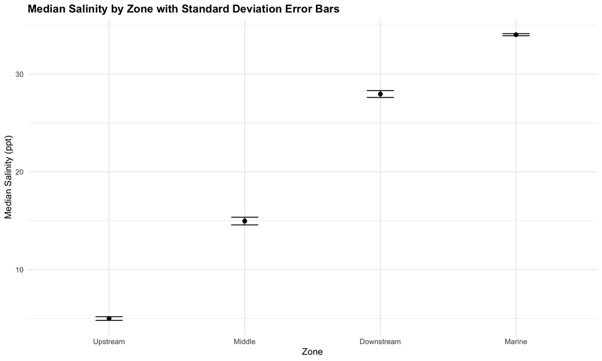

```r
sal_sum |>
  ggplot(aes(x = zone, y = median_salinity)) +
  geom_point(size = 2) +
  geom_errorbar(aes(ymin = median_salinity - sd_salinity, ymax = median_salinity + sd_salinity), width = 0.2) +
  theme_minimal() +
  labs(title = "Median Salinity by Zone with Standard Deviation Error Bars",
       x = "Zone",
       y = "Median Salinity (ppt)") +
  theme(plot.title = element_text(face = "bold"))
```

## 7.2 Turbidity

```r
turb_sum <- catch_data_final |>
  group_by(zone) |>
  summarise(
    sd_turbidity = sd(mean_turbidity, na.rm = TRUE),
    median_turbidity = median(mean_turbidity, na.rm = TRUE),
    .groups = "drop"
  )

turb_sum
```

| zone | sd_turbidity | median_turbidity |
| --- | --- | --- |
| Upstream | 1.626597 | 25.19350 |
| Middle | 1.252903 | 25.70855 |
| Downstream | 1.642192 | 25.22267 |
| Marine | 1.266353 | 25.54743 |

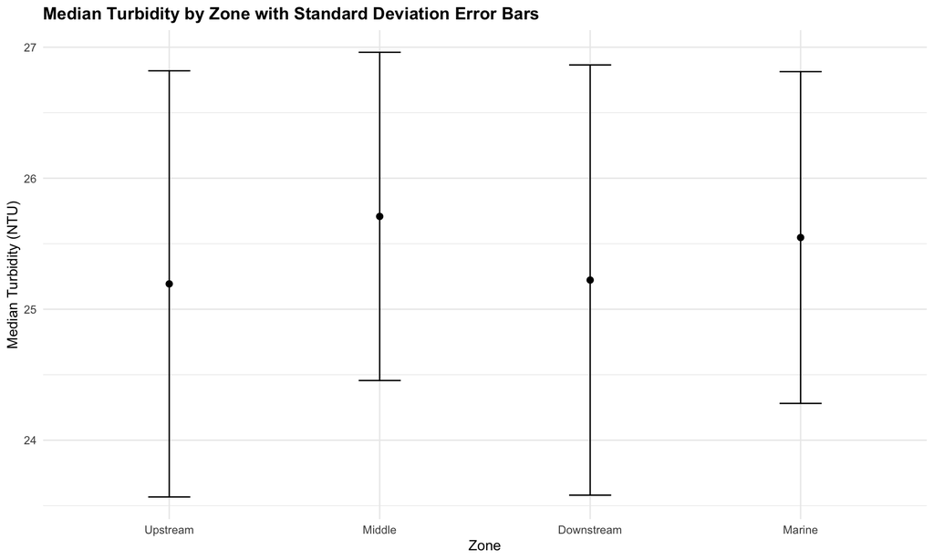

```r
turb_sum |>
  ggplot(aes(x = zone, y = median_turbidity)) +
  geom_point(size = 2) +
  geom_errorbar(aes(ymin = median_turbidity - sd_turbidity, ymax = median_turbidity + sd_turbidity), width = 0.2) +
  theme_minimal() +
  labs(title = "Median Turbidity by Zone with Standard Deviation Error Bars",
       x = "Zone",
       y = "Median Turbidity (NTU)") +
  theme(plot.title = element_text(face = "bold"))
```

## 7.3 Temperature

```r
temp_sum <- catch_data_final |>
  group_by(zone) |>
  summarise(
    sd_temperature = sd(mean_temp, na.rm = TRUE),
    median_temperature = median(mean_temp, na.rm = TRUE),
    .groups = "drop"
  )

temp_sum
```

| zone | sd_temperature | median_temperature |
| --- | --- | --- |
| Upstream | 0.1397788 | 24.02643 |
| Middle | 0.1292683 | 23.98330 |
| Downstream | 0.1256290 | 23.99401 |
| Marine | 0.1709186 | 23.95526 |

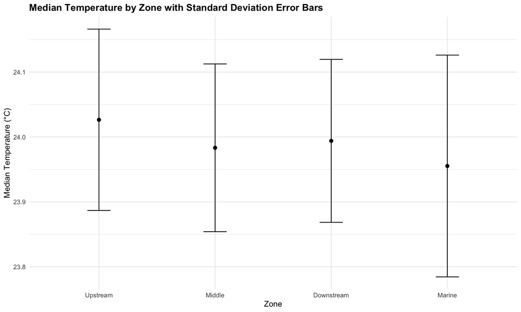

```r
temp_sum |>
  ggplot(aes(x = zone, y = median_temperature)) +
  geom_point(size = 2) +
  geom_errorbar(aes(ymin = median_temperature - sd_temperature, ymax = median_temperature + sd_temperature),
                width = 0.2) +
  theme_minimal() +
  labs(title = "Median Temperature by Zone with Standard Deviation Error Bars",
       x = "Zone",
       y = "Median Temperature (°C)") +
  theme(plot.title = element_text(face = "bold"))
```

## 7.4 Remake salinity plot nicely for publication

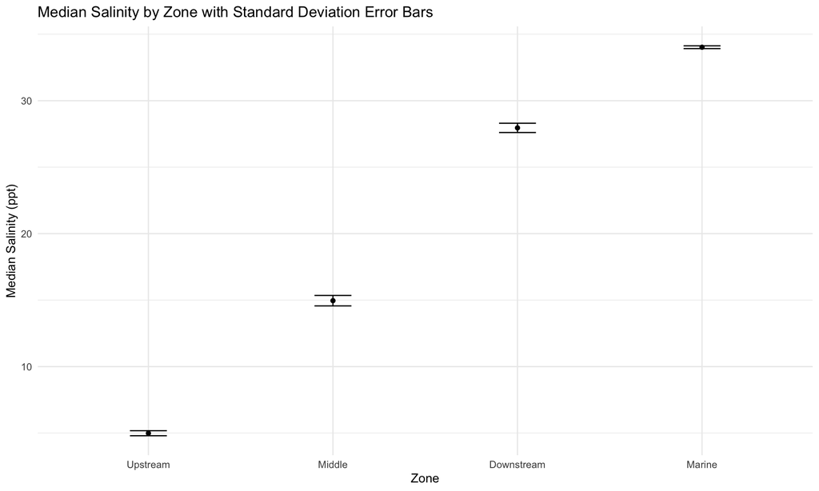

Salinity Gradient across zones. Ross River Estuary System, Townsville, NQ, Australia May 2026.

```r
sal_sum |>
  ggplot(aes(x = zone, y = median_salinity)) +
  geom_point() +
  geom_errorbar(aes(ymin = median_salinity - sd_salinity, ymax = median_salinity + sd_salinity), width = 0.2) +
  theme_minimal() +
  labs(title = "Median Salinity by Zone with Standard Deviation Error Bars",
       x = "Zone",
       y = "Median Salinity (ppt)")
```

## 7.5 Patterns in Fish Abundance

### 7.5.1 Calculate summary stats

```r
fish_stats <- catch_data_final |>
  group_by(zone, scientific_name) |>
  summarise(
    mean_catch = mean(count),
    sem_catch = sd(count) / sqrt(n()),
    .groups = "drop"
  )

fish_stats
```

| zone | scientific_name | mean_catch | sem_catch |
| --- | --- | --- | --- |
| Upstream | Acanthopagrus spp. | 2.566667 | 0.3020365 |
| Upstream | Lates calcarifer | 4.800000 | 0.3085003 |
| Upstream | Lutjanus argentimaculatus | 1.900000 | 0.2109094 |
| Upstream | Platycephalus spp. | 2.300000 | 0.3327005 |
| Middle | Acanthopagrus spp. | 2.233333 | 0.2864099 |
| Middle | Lates calcarifer | 2.200000 | 0.2416419 |
| Middle | Lutjanus argentimaculatus | 1.966667 | 0.2061320 |
| Middle | Platycephalus spp. | 1.966667 | 0.2647199 |
| Downstream | Acanthopagrus spp. | 2.000000 | 0.2754307 |
| Downstream | Lates calcarifer | 1.600000 | 0.2564120 |

[output cut: 6 more lines]

### 7.5.2 Summary stats plot

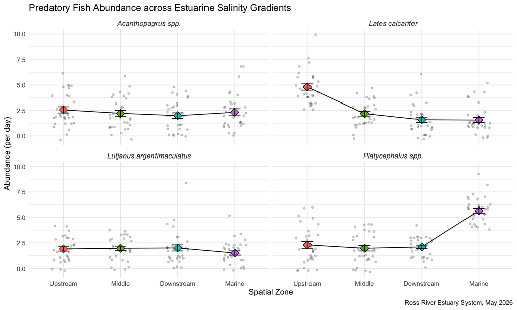

```r
fish_stats |>
  ggplot(aes(x = zone, y = mean_catch, fill = zone)) +
  geom_line(group = 1) +
  # add in points from master data
  geom_point(data = catch_data_final, aes(x = zone, y = count),
             position = position_jitter(width = 0.2), alpha = 0.2, size = 1, inherit.aes = FALSE) +

  geom_point(position = "dodge", size = 4, pch = 23) +

  geom_errorbar(aes(ymin = mean_catch - sem_catch, ymax = mean_catch + sem_catch),
                position = position_dodge(0.9), width = 0.2) +

  facet_wrap(~ scientific_name, scales = "fixed") +
  theme_minimal() +
  theme(
    strip.text = element_text(face = "italic", size = 10, colour = "grey20"),
    legend.position = "none"
  ) +
  labs(
    title = "Predatory Fish Abundance across Estuarine Salinity Gradients",
    caption = "Ross River Estuary System, May 2026",
    x = "Spatial Zone",
    y = "Abundance (per day)",
    fill = "Spatial Zone"
    )
```

From this plot we can see that *Acanthopagrus spp.* and *Lutjanus argentimaculatus* have very a very similar abundance across the different spatial zones of the Ross River. *Lates calcarifer* was twice as abundant in the upstream spatial zone compared to all other zones, implying that this species prefers very low salinity concentrations. *Platycephalus spp.* was twice as abundant in the marine spatial zone than all other zones, implying that this species prefers high salinity concentrations.